# R Notebook

# Intervalo de Confianza para muestras de tamanho menores o iguales a 30

$$LI = \mu - t_{(1-\frac{\alpha}{2}, n -1)}*\frac{S}{\sqrt{n}}$$
$$LS = \mu + t_{(1-\frac{\alpha}{2}, n -1)}*\frac{S}{\sqrt{n}}$$

```r
# Para poblaciones con n <= 30
# Calcular el intervalo de confianza
# mestra :  la muestra
# nconf : nivel de confianza
ic_media <- function(muestra, nconf = 0.95){

  # El alpha es el complemento del nivel de confianza
  alpha = 1 - nconf
  n = length(muestra)
  s = sd(muestra)  # desviacion estandard
  mu = mean(muestra)
  me = qt(1-alpha/2, n-1) * s / sqrt(n)
  print(mu - me)
  print(mu + me)

}
```

```r
muestra = c(10.5, 8.6, 7.4 , 6.7, 9.1, 11.2 , 12, 10 )
ic_media(muestra)
```

```
[1] 7.903136
[1] 10.97186
```

```r
# x : Diametro de las botellas (cm)
```

Cuando un 95 % de confianza se puede afirmar que la media poblacion del diametro de la botella esta entre 7.9 y 10.97

# Intervalo de Confianza para muestras de tamanho mayores a 30

$$LI = \mu - Z_{(1-\frac{\alpha}{2})}*\frac{S}{\sqrt{n}}$$
$$LS = \mu + Z_{(1-\frac{\alpha}{2})}*\frac{S}{\sqrt{n}}$$
Falta implementar

# metodo estandar.

la siguiente función calcula la curtosis de un vector x

```r
curtosis <- function(x) {
  curtosis <- sum(((x-mean(x))/sd(x))^4)/(length(x)-1) - 3
  curtosis
}
```

La siguiente función calcula el intervalo de confianza para la curtosis a través del método estandar.

```r
curtosisicb=function(datos,q,b,alpha) {
  #q es la columna de la data que se va a trabajar
  #b es el numero de muestra bootstrap
  #alpha es el nivel significacion de 0 a 1
  n=dim(datos)[1]
  curtosisbvec=rep(0,b)
  for (i in 1:b){
    data=1:n
    mcr=sample(data,n,T)
    datosb=datos[mcr,q]
    curtosisbvec[i]=curtosis(datosb)
  }
  meanb=mean(curtosisbvec)
  sdb=sd(curtosisbvec)
  lis=meanb-qnorm(1-alpha/2)*sdb
  lss=meanb+qnorm(1-alpha/2)*sdb
  print(lis)
  print(lss)
  anchoi=lss-lis
  print(anchoi)
}
```

La funcion curtosis esta hecha para un vector

```r
curtosisicb(iris,1,100,0.05)
```

```
[1] -0.9239552
[1] -0.222997
[1] 0.7009583
```

```r
curtosisicb(iris,1,1000,0.05)
```

```
[1] -0.9449438
[1] -0.2179988
[1] 0.726945
```

## Método de los Percentiles

El calculos de los percentiles puede ser aplicacion con la funcion de distribucion Z No importa que la funcion de distribucion sea simetrica o no.

la siguiente función calcula la curtosis de un vector x

```r
curtosis <- function(x) {
  curtosis <- sum(((x-mean(x))/sd(x))^4)/(length(x)-1) - 3
  curtosis
}
```

La siguiente funcion calcula el intervalo de confianza para la curtosis a travez del metodo percentiles.

```r
# q es la columna de la data que se va a trabajar
# b es el numero de muestra bootstrap
# alpha es el nivel significacion de 0 a 1
curtosisicbp = function(datos,q,b,alpha){

  n = dim(datos)[1]
  curtosisbvec = rep(0,b)

  for (i in 1:b){
    data=1:n
    mcr=sample(data,n,T)
    datosb=datos[mcr,q]
    curtosisbvec[i]=curtosis(datosb)
  }

  hist(curtosisbvec)
  curtosisvec = sort(curtosisbvec)
  lis=quantile(curtosisvec,alpha/2)
  lss=quantile(curtosisvec,1-alpha/2)
  print(lis)
  print(lss)
  anchoi = as.numeric(lss-lis)
  print(anchoi)
}
```

Calcula 100 veces la curtosis

```
        5%
-0.8829593
       95%
-0.3173086
[1] 0.5656507
```

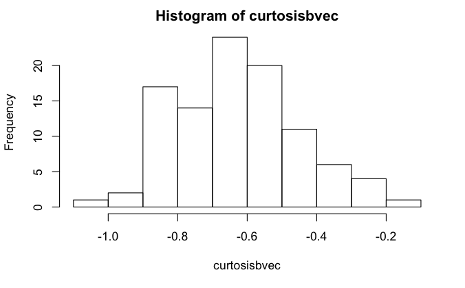

```r
curtosisicbp(iris,1,100,0.10)
```

# Método bootstrapping estudentizado

la siguiente funcion calcula la curtosis de un vector x

```r
curtosis <- function(x) {
  curtosis <- sum(((x-mean(x))/sd(x))^4)/(length(x)-1) - 3
  curtosis
}
```

La siguiente función calcula el intervalo de confianza para la curtosis a través del método estudentizado.

```r
#q es la columna de la data que se va a trabajar
#b es el numero de muestra bootstrap
#alpha es el nivel significacion de 0 a 1
curtosisicstud=function(datos,q,b,alpha){

  n=dim(datos)[1]
  curtosisbvec=rep(0,b)

  for (i in 1:b){
    data=1:n
    mcr=sample(data,n,T)
    datosb=datos[mcr,q]
    curtosisbvec[i]=curtosis(datosb)
  }

  escurtosisb=sd(curtosisbvec)
  testud=rep(0,b)  # Inicializa el estudentizado
  curtorig=curtosis(datos[,q])

  # No se necesita el for: VERIFICAR
  for (j in 1:b)
    testud[j]=(curtosisbvec[j]-curtorig)/escurtosisb  # La curtosis de los vectores

  stestud=sort(testud)
  lis=curtorig+quantile(stestud,alpha/2)*escurtosisb
  lss=curtorig+quantile(stestud,1-alpha/2)*escurtosisb
  print(lis)
  print(lss)
  anchoi=as.numeric(lss-lis)
  print(anchoi)
}
```

```r
curtosisicstud(iris,1,100,0.10)
```

```
        5%
-0.8779609
       95%
-0.2910964
[1] 0.5868645
```